# Logistic Regression with Python

For this lecture we will be working with the [Titanic Data Set from Kaggle](https://www.kaggle.com/c/titanic). This is a very famous data set.

We'll be trying to predict a classification- survival or deceased. Let's begin our understanding of implementing Logistic Regression in Python for classification.

We'll use a "semi-cleaned" version of the titanic data set, if you use the data set hosted directly on Kaggle, you may need to do some additional cleaning.

## Import Libraries

Let's import some libraries to get started!

```python
import pandas as pd
import numpy as np
import matplotlib.pyplot as plt
import seaborn as sns
%matplotlib inline
```

## The Data

Let's start by reading in the titanic_train.csv file into a pandas dataframe.

```python
train = pd.read_csv('titanic_train.csv')
```

```python
train.head()
```

|  | PassengerId | Survived | Pclass | Name | Sex | Age | SibSp | Parch | Ticket | Fare | Cabin | Embarked |
| --- | --- | --- | --- | --- | --- | --- | --- | --- | --- | --- | --- | --- |
| 0 | 1 | 0 | 3 | Braund, Mr. Owen Harris | male | 22.0 | 1 | 0 | A/5 21171 | 7.2500 | NaN | S |
| 1 | 2 | 1 | 1 | Cumings, Mrs. John Bradley (Florence Briggs Th... | female | 38.0 | 1 | 0 | PC 17599 | 71.2833 | C85 | C |
| 2 | 3 | 1 | 3 | Heikkinen, Miss. Laina | female | 26.0 | 0 | 0 | STON/O2. 3101282 | 7.9250 | NaN | S |
| 3 | 4 | 1 | 1 | Futrelle, Mrs. Jacques Heath (Lily May Peel) | female | 35.0 | 1 | 0 | 113803 | 53.1000 | C123 | S |
| 4 | 5 | 0 | 3 | Allen, Mr. William Henry | male | 35.0 | 0 | 0 | 373450 | 8.0500 | NaN | S |

# Exploratory Data Analysis

Let's begin some exploratory data analysis! We'll start by checking out missing data!

## Missing Data

We can use seaborn to create a simple heatmap to see where we are missing data!

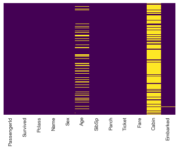

```python
sns.heatmap(train.isnull(),yticklabels=False,cbar=False,cmap='viridis')
```

Roughly 20 percent of the Age data is missing. The proportion of Age missing is likely small enough for reasonable replacement with some form of imputation. Looking at the Cabin column, it looks like we are just missing too much of that data to do something useful with at a basic level. We'll probably drop this later, or change it to another feature like "Cabin Known: 1 or 0"

Let's continue on by visualizing some more of the data!

[output not shown]

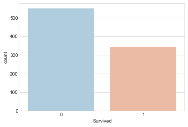

```python
sns.set_style('whitegrid')
sns.countplot(x='Survived',data=train,palette='RdBu_r') #shows the count of people who survived and who didn't survived..
```

[output not shown]

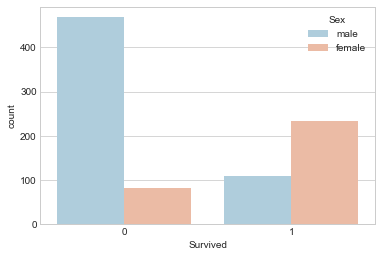

```python
sns.set_style('whitegrid')
sns.countplot(x='Survived',hue='Sex',data=train,palette='RdBu_r')
#shows count of 'Survived' column along with the 'Sex' column that is sex-wise count of people.
```

[output not shown]

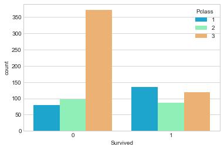

```python
sns.set_style('whitegrid')
sns.countplot(x='Survived',hue='Pclass',data=train,palette='rainbow')
```

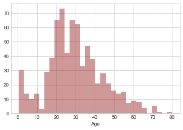

```python
sns.distplot(train['Age'].dropna(),kde=False,color='darkred',bins=30)
#dropna() is used to remove the NaN values while plotting the distance plot.
```

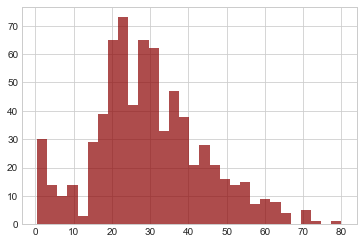

```python
#another way to plot the histogram as above.
train['Age'].hist(bins=30,color='darkred',alpha=0.7)
```

[output not shown]

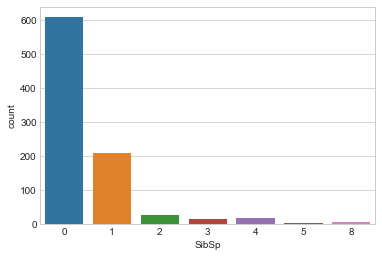

```python
sns.countplot(x='SibSp',data=train)
#count of siblings and spouses.
```

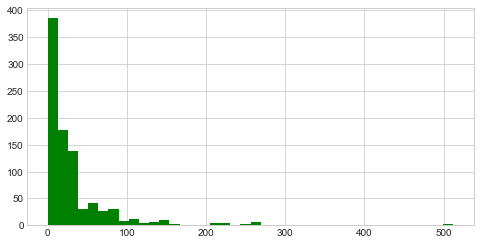

```python
train['Fare'].hist(color='green',bins=40,figsize=(8,4))
#shows that the most people have bought the ticket for fare ranging between 0 to 100.
```

## Data Cleaning

We want to fill in missing age data instead of just dropping the missing age data rows. One way to do this is by filling in the mean age of all the passengers (imputation). However we can be smarter about this and check the average age by passenger class. For example:

[output not shown]

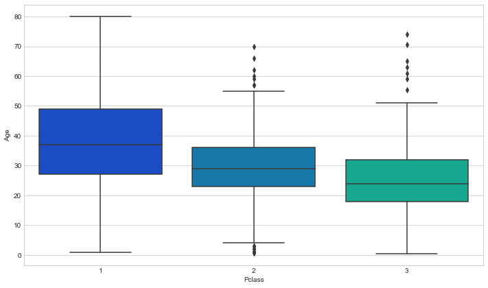

```python
plt.figure(figsize=(12, 7))
sns.boxplot(x='Pclass',y='Age',data=train,palette='winter')
```

We can see the wealthier passengers in the higher classes tend to be older, which makes sense. We'll use these average age values to impute based on Pclass for Age.

```python
def impute_age(cols):  #assigns the value to the missing 'Age' values based on the class-wise average mean of ages.
    Age = cols[0]
    Pclass = cols[1]

    if pd.isnull(Age):

        if Pclass == 1:
            return 37  #based on the avg. mean for Pclass=1 from the above boxplot

        elif Pclass == 2:
            return 29    #based on the avg. mean for Pclass=2 from the above boxplot

        else:
            return 24   #based on the avg. mean for Pclass=3 from the above boxplot

    else:
        return Age #else if the value is not null,keep the 'Age' same as in the original dataset
```

Applying the above function

```python
train['Age']=train[['Age','Pclass']].apply(impute_age,axis=1)
```

Creating the heatmap again to check whether the null values appear for 'Age' column or not.

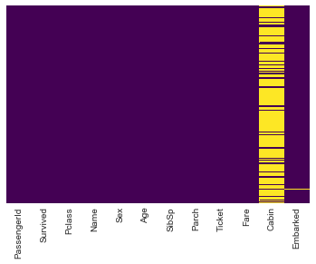

```python
sns.heatmap(train.isnull(),yticklabels=False,cbar=False,cmap='viridis')
```

The yellow mark only for one row of 'Embarked' column and 'Cabin' column shows that there are no null values now for the 'Age' column.

```python
train.drop('Cabin',axis=1,inplace=True)
```

```python
train.head()
#no column 'Cabin' in thje dataset now.
```

|  | PassengerId | Survived | Pclass | Name | Sex | Age | SibSp | Parch | Ticket | Fare | Embarked |
| --- | --- | --- | --- | --- | --- | --- | --- | --- | --- | --- | --- |
| 0 | 1 | 0 | 3 | Braund, Mr. Owen Harris | male | 22.0 | 1 | 0 | A/5 21171 | 7.2500 | S |
| 1 | 2 | 1 | 1 | Cumings, Mrs. John Bradley (Florence Briggs Th... | female | 38.0 | 1 | 0 | PC 17599 | 71.2833 | C |
| 2 | 3 | 1 | 3 | Heikkinen, Miss. Laina | female | 26.0 | 0 | 0 | STON/O2. 3101282 | 7.9250 | S |
| 3 | 4 | 1 | 1 | Futrelle, Mrs. Jacques Heath (Lily May Peel) | female | 35.0 | 1 | 0 | 113803 | 53.1000 | S |
| 4 | 5 | 0 | 3 | Allen, Mr. William Henry | male | 35.0 | 0 | 0 | 373450 | 8.0500 | S |

```python
train.dropna(inplace=True)
```

```python
train['Embarked'][61]
```

[output not shown]

## Converting Categorical Features

We'll need to convert categorical features to dummy variables using pandas! Otherwise our machine learning algorithm won't be able to directly take in those features as inputs.

```python
train.info()
```

```
<class 'pandas.core.frame.DataFrame'>
Int64Index: 889 entries, 0 to 890
Data columns (total 11 columns):
PassengerId    889 non-null int64
Survived       889 non-null int64
Pclass         889 non-null int64
Name           889 non-null object
Sex            889 non-null object
Age            889 non-null float64
SibSp          889 non-null int64
Parch          889 non-null int64
Ticket         889 non-null object
Fare           889 non-null float64
Embarked       889 non-null object
dtypes: float64(2), int64(5), object(4)
memory usage: 101.5+ KB
```

```python
train['Embarked'].unique()
```

```
array(['S', 'C', 'Q'], dtype=object)
```

```python
#creating dummy variables
#get_dummies basically converts the categorical variables into dummies or indicating variables.

sex=pd.get_dummies(train['Sex'],drop_first=True)
```

```python
sex.head()
```

|  | male |
| --- | --- |
| 0 | 1 |
| 1 | 0 |
| 2 | 0 |
| 3 | 0 |
| 4 | 1 |

```python
embark=pd.get_dummies(train['Embarked'],drop_first=True)

#we drop the first column because the other 2 columns collectively can define the value of the first column and hence it
#would be fine even without the first column.
```

```python
embark.head()
```

|  | Q | S |
| --- | --- | --- |
| 0 | 0 | 1 |
| 1 | 0 | 0 |
| 2 | 0 | 1 |
| 3 | 0 | 1 |
| 4 | 0 | 1 |

```python
#dropping the non-numerical columns
train.drop(['Sex','Name','Embarked','Ticket'],axis=1,inplace=True) #inplace=True for changes to be permanent
```

```python
#train after dropping non-numerical values
train.head()
```

|  | PassengerId | Survived | Pclass | Age | SibSp | Parch | Fare |
| --- | --- | --- | --- | --- | --- | --- | --- |
| 0 | 1 | 0 | 3 | 22.0 | 1 | 0 | 7.2500 |
| 1 | 2 | 1 | 1 | 38.0 | 1 | 0 | 71.2833 |
| 2 | 3 | 1 | 3 | 26.0 | 0 | 0 | 7.9250 |
| 3 | 4 | 1 | 1 | 35.0 | 1 | 0 | 53.1000 |
| 4 | 5 | 0 | 3 | 35.0 | 0 | 0 | 8.0500 |

```python
#Concatenating the existing 'train' dataset with the new 'sex' and 'embark' columns to get all numerical columns

train=pd.concat([train,sex,embark],axis=1)
```

```python
#new 'Train' dataset
train.head()
```

|  | PassengerId | Survived | Pclass | Age | SibSp | Parch | Fare | male | Q | S |
| --- | --- | --- | --- | --- | --- | --- | --- | --- | --- | --- |
| 0 | 1 | 0 | 3 | 22.0 | 1 | 0 | 7.2500 | 1 | 0 | 1 |
| 1 | 2 | 1 | 1 | 38.0 | 1 | 0 | 71.2833 | 0 | 0 | 0 |
| 2 | 3 | 1 | 3 | 26.0 | 0 | 0 | 7.9250 | 0 | 0 | 1 |
| 3 | 4 | 1 | 1 | 35.0 | 1 | 0 | 53.1000 | 0 | 0 | 1 |
| 4 | 5 | 0 | 3 | 35.0 | 0 | 0 | 8.0500 | 1 | 0 | 1 |

# Building a Logistic Regression model

Let's start by splitting our data into a training set and test set (there is another test.csv file that you can play around with in case you want to use all this data for training).

## Train Test Split

```python
from sklearn.model_selection import train_test_split
```

```python
X=train.drop('Survived',axis=1)  #every column except the one which we will be predicting values for.
Y=train['Survived']  #variable values to be predicted
```

```python
X_train, X_test, Y_train, Y_test = train_test_split(X, Y, test_size=0.33, random_state=101)
```

## Training and Predicting

```python
from sklearn.linear_model import LogisticRegression
```

```python
logreg=LogisticRegression()
```

```python
logreg.fit(X_train,Y_train)
```

```
LogisticRegression(C=1.0, class_weight=None, dual=False, fit_intercept=True,
          intercept_scaling=1, max_iter=100, multi_class='ovr', n_jobs=1,
          penalty='l2', random_state=None, solver='liblinear', tol=0.0001,
          verbose=0, warm_start=False)
```

```python
predictions=logreg.predict(X_test)
```

## Evaluation

```python
from sklearn.metrics import classification_report
```

```python
print(classification_report(Y_test,predictions))
```

```
             precision    recall  f1-score   support

          0       0.79      0.91      0.85       174
          1       0.84      0.65      0.73       120

avg / total       0.81      0.81      0.80       294
```